# case study 4 v3

Lance Dacy, Reanan McDaniel, Shawn Jung, Jonathan Tan

```r
#analysis packages
library(tswge)
library(changepoint)
library(tseries)
library(DataExplorer)
library(nnfor)
#data manipulation
library(dplyr)
library(lubridate)
library(tibbletime)
```

```r
#visualization
library(ggplot2)
library(cowplot)
library(kableExtra)
#data source
library(cdcfluview)
```

import data from… ??? https://apps.who.int/flumart/Default?ReportNo=12 query below is SE Asia from 1995 to 2019

```r
raw_data  <- read.csv('D:/SMU/DS 7333 Quantify The World/FluNetInteractiveReport_SE_Asia_1995-2019.csv')
```

Column guide for WHO data csv columns

SPEC_RECIEVED_NB - Specimens recieved by the WHO

SPEC_PROCESSED_NB - specimens processed by the WHO

AH1 - all A type influenza viruses categorized by subtype

A(H1N1pdm09

AH3

AH5

ANOTSUBTYPED

INF(A) - total of all influenza A viruses detected

BYAMAGATA - B(Yamagata lineage) - various types of influenze B type viruses

BVICTORIA - B(Victoria Lineage)

BNOTDETERMINED

INF_B - total influenze B viruses

ALL_INF - number of influenze positive viruses

ALL_INF2 - number of influenze negative viruses

TITLE - ili activity? most have no report as the column

will have to look more into the details, but it looks like this dataset is recording the number of virus strains, not individual cases of that virus. specimens recieved/processed usually matches up with INF + or -, indicating that those specimens were all tested and sorted into either yes, it was an influenza virus, or no, it was not.

We’ll pick S asia, India for total influenza cases

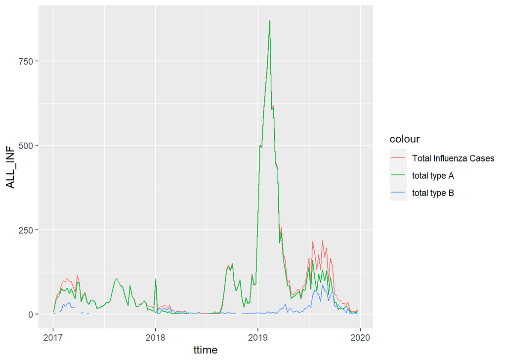

```r
S_Asia <- raw_data[which(raw_data$FLUREGION == 'Southern Asia'), ] #select rows from SE asia
tlist <- S_Asia[complete.cases(S_Asia$ALL_INF), ] #select only rows that aren't missing data in the all_inf column
t_ind <- tlist[which(tlist['ï..Country'] == 'India'), ]
t_ind <- t_ind[which(t_ind$Year == 2017| t_ind$Year == 2018 | t_ind$Year == 2019), ] #select 3 years
ttime = t_ind$SDATE %>% as.Date("%m/%d/%Y") #store the timeline as date object vector
#it looks like all the weeks fall on the same SDATE's, so it should be safe to use the same date vector for different countries.

ggplot(t_ind) +
  geom_line(aes(x = ttime, y = ALL_INF, col = 'Total Influenza Cases'))+
  #geom_line(aes(x = ttime, y = AH1, col = 'AH1'))+
  #geom_line(aes(x = ttime, y = AH1N12009, col = '2009 Swine Flu'))+
  #geom_line(aes(x = ttime, y = AH3, col = 'AH3'))+
  #geom_line(aes(x = ttime, y = AH5, col = 'AH5'))+
  #geom_line(aes(x = ttime, y = ANOTSUBTYPED, col = 'Untyped Inf A'))+
  geom_line(aes(x = ttime, y = INF_A, col = 'total type A'))+
  #geom_line(aes(x = ttime, y = BYAMAGATA, col = 'Yamagata STRAIN B'))+
  #geom_line(aes(x = ttime, y = BVICTORIA, col = 'Victoria Strain B'))+
  #geom_line(aes(x = ttime, y = BNOTDETERMINED, col = 'Untyped Inf B'))+
  geom_line(aes(x = ttime, y = INF_B, col = 'total type B')) +
  scale_y_continuous()
```

diagnostics, stationarity

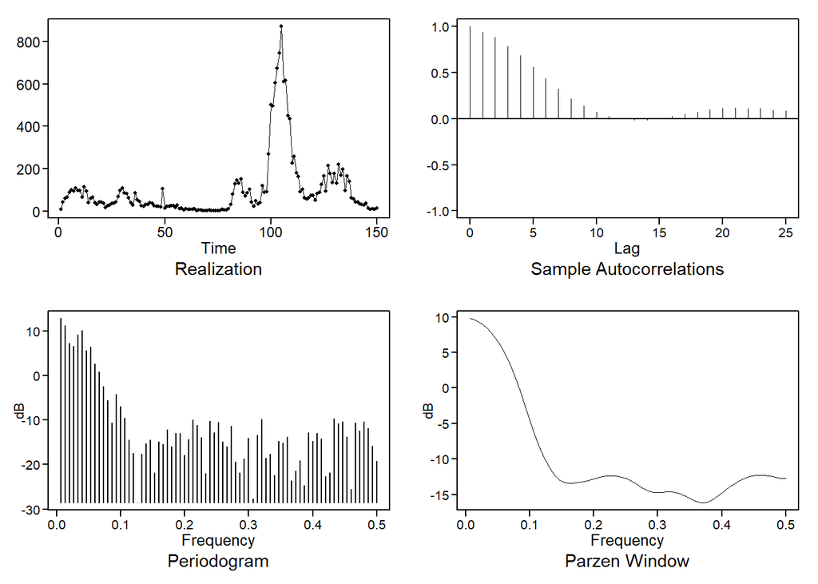

```r
tdata = t_ind$ALL_INF
#wrap objects in invisible() to hide the long console output and leave only the graph
invisible(plotts.sample.wge(tdata))
```

```r
#stationairity
adf.test(tdata)
```

```
##
##  Augmented Dickey-Fuller Test
##
## data:  tdata
## Dickey-Fuller = -4.3055, Lag order = 5, p-value = 0.01
## alternative hypothesis: stationary
```

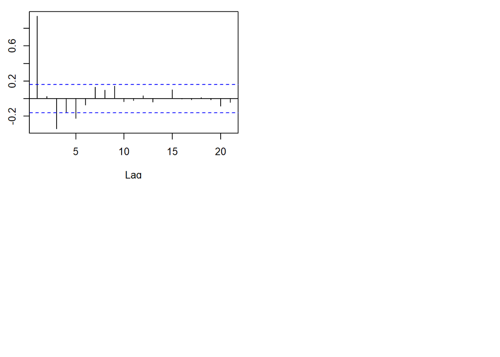

```r
pacf(tdata)
#changepoint
par(mfrow = c(2,1))
```

```r
v2 <- tdata
v2.pelt <- cpt.meanvar(v2, test.stat = 'Poisson', method = "PELT")
plot(v2.pelt, main = 'PELT changes in variance')
cpts.ts(v2.pelt)
```

```
##  [1]   2   4  13  16  27  32  38  47  49  56  64  80  82  86  90  95  98 101 103
## [20] 105 107 109 111 113 123 126 134 137 139 145
```

```r
v2.bs <- cpt.meanvar(v2, test.stat = 'Poisson', method = 'BinSeg')
```

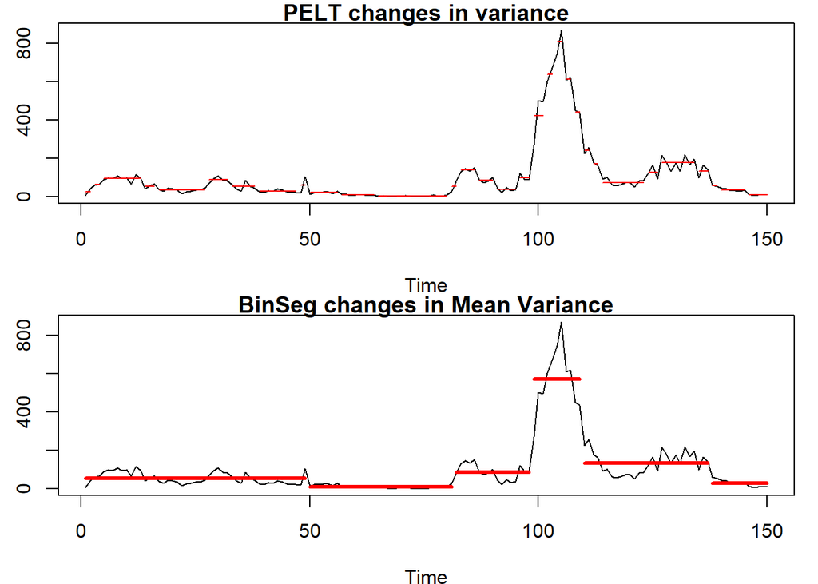

```r
plot(v2.bs, cpt.width = 3, main = 'BinSeg changes in Mean Variance')
```

```r
cpts.ts(v2.bs)
```

```
## [1]  49  81  98 109 137
```

feed into modeling block

modelling block parts -

AIC5.wge returns the 5 lowest AIC values, used to determine the number of p and q coefficients for the AutoRegressive and Moving Average parts of ARIMA, respectively

est.arma.wge takes the time series object and the number of p and q terms as arguments to estimate the coefficients for those p and q terms

fore.aruma.wge takes the coeficients and forecasts a specified number of units forwards

```r
#model fitting with tdata
pspan = 0:10 #range of values to look for possible p and q coefficients for AR and MA
qspan = 0:8
difference = 0
aic_results <- aic5.wge(tdata, p = pspan, q = qspan)
```

```
## ---------WORKING... PLEASE WAIT...
##
##
## Five Smallest Values of  aic
```

```r
bic_results <- aic5.wge(tdata, p = pspan, q = qspan, type = 'bic')
```

```
## ---------WORKING... PLEASE WAIT...
##
##
## Five Smallest Values of  bic
```

```r
aic_results
```

```
##       p    q        aic
## 32    3    4   7.681212
## 16    1    6   7.683209
## 34    3    6   7.684040
## 23    2    4   7.686687
## 17    1    7   7.690025
```

```r
bic_results
```

```
##       p    q        bic
## 21    2    2   7.802110
## 14    1    4   7.814297
## 30    3    2   7.826343
## 23    2    4   7.827183
## 15    1    5   7.832998
```

```r
m1 = est.arma.wge(tdata, p = aic_results[1, 1], q = aic_results[1, 2], factor = TRUE) #feed top AIC or BIC into arma estimation to generate coefficients
```

```
##
## Coefficients of Original polynomial:
## 1.1622 -0.0434 -0.2316
##
## Factor                 Roots                Abs Recip    System Freq
## 1-1.5366B+0.6187B^2    1.2419+-0.2722i      0.7866       0.0343
## 1+0.3744B             -2.6710               0.3744       0.5000
##
##
```

```r
m1$phi
```

```
## [1]  1.16224819 -0.04338446 -0.23162370
```

```r
m1$theta
```

```
## [1]  0.3861406 -0.1622587 -0.1475116 -0.3263750
```

```r
#simple single forecast and test
weeks_compare = 24 #how many weeks to reserve for testing : 6months
f1 <- tdata[1:(length(tdata)-weeks_compare)] %>% fore.aruma.wge(phi = m1$phi, theta = m1$theta, d = 0, n.ahead = weeks_compare)
```

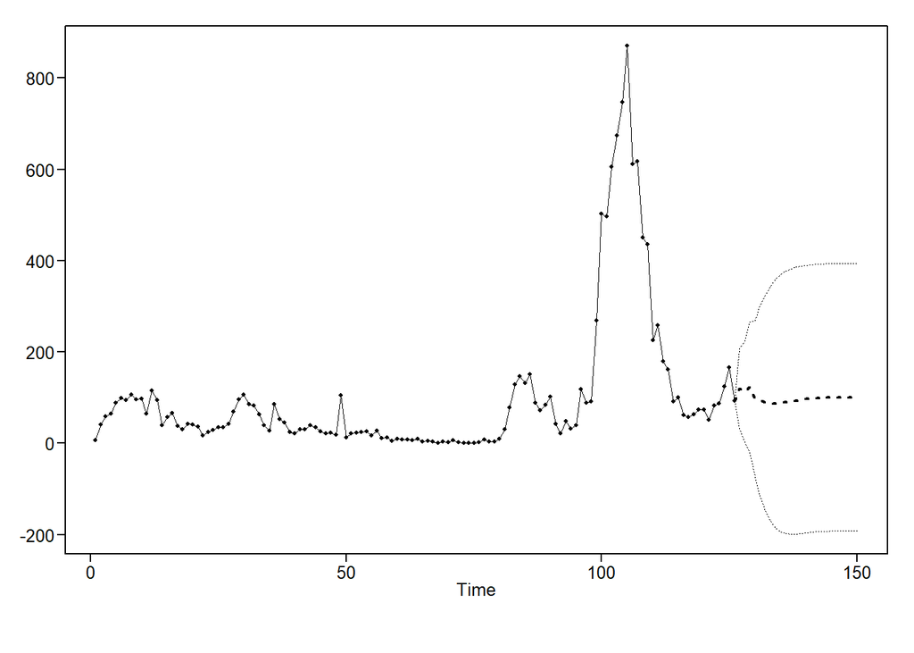

```r
mse <- mean((tdata[((length(tdata)-weeks_compare)+1):(length(tdata))] - f1$f)^2)
paste('Mean Squared Error: ', mse)
```

```
## [1] "Mean Squared Error:  5577.11256113999"
```

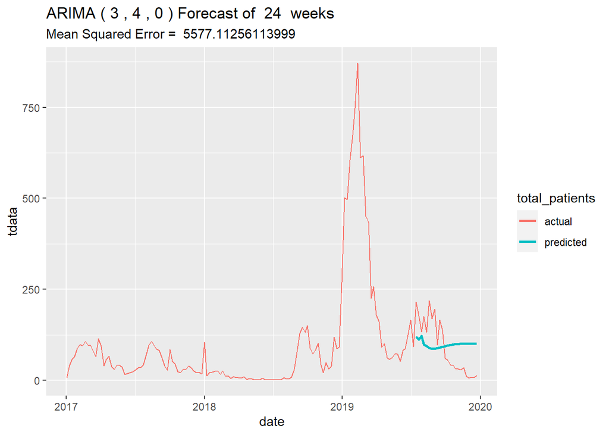

```r
#additional metrics
a_metrics <- accuracy(f1$f, tdata[((length(tdata)-weeks_compare)+1):(length(tdata))] )

#change x and y line names to match whatever dataframe you've stored the time series in
timeFrame <- data.frame(date = ttime, inf_cases = tdata)
g3 <- ggplot(timeFrame)+
  geom_line(aes(x = date, y = tdata, color = 'black'), size = 0.5)+
  geom_line(aes(x = date, y = c(rep(NA, length(tdata)-weeks_compare), f1$f), color = 'red'), size= 1) +
  scale_color_discrete(name = "total_patients", labels = c('actual', 'predicted')) +
  ggtitle(paste('ARIMA (',aic_results[1, 1],',',aic_results[1, 2],',',difference,')', 'Forecast of ', weeks_compare, ' weeks'), subtitle = paste('Mean Squared Error = ', mse))
g3
```

training size = how many weeks to use as training data horizon = how many weeks to use as testing data step_size - how far to move the “window” every iteration

breaks up the time series object into a slices of specified length, evaluate using the mean of all ASE at the end

lets you know how well a model generalizes across the “body” of the time series, or if it only good before a spike, when stationary, ect

```r
#updated with step size,how much the "window" moves per interval
#rolling window ase: apply model predictions to small segments of the given data and aggregate metrics
trainingSize = 24
horizon = 4
step_size = 8
n_windows = round((length(tdata)-(trainingSize + horizon))/step_size) #number of whole windows of training size + horizon that will fit into the given data, divided by step size
ASEHolder = numeric()

fcastHolder = matrix(nrow = n_windows, ncol = horizon) #create matrix that has the number of rows and columns corresponding to number of windows and length of forecast interval
fUpperHolder = matrix(nrow = n_windows, ncol = horizon) #same for upper and lower intervals
fLowerHolder = matrix(nrow = n_windows, ncol = horizon)
phis = m1$phi
thetas = m1$theta
s = 0
d = 0

for( i in 1:n_windows) #how many "windows" can fit into the total length of time, rounding down
{
  t_start = 1+(step_size*(i-1)) #starting point for each window's training data
  t_end = trainingSize + (step_size*(i-1)) #endpoint
  forecasts = fore.aruma.wge(tdata[t_start:t_end],phi = phis, theta = thetas, s = s, d = d, n.ahead = horizon)

  ASE = mean((tdata[(t_end + 1):(t_end+horizon)] - forecasts$f)^2)
  ASEHolder[i] = ASE
  fcastHolder[i, ] <- forecasts$f
  fUpperHolder[i, ] <- forecasts$ul
  fLowerHolder[i, ] <- forecasts$ll
  #print(paste(t_start, t_end))
}
```

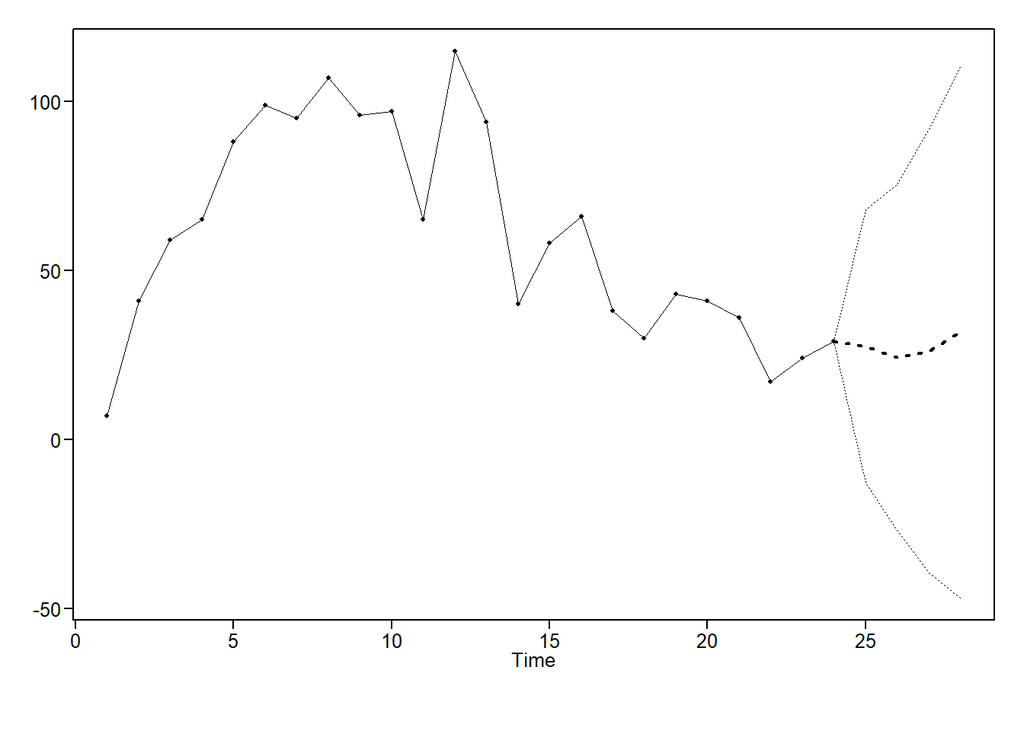

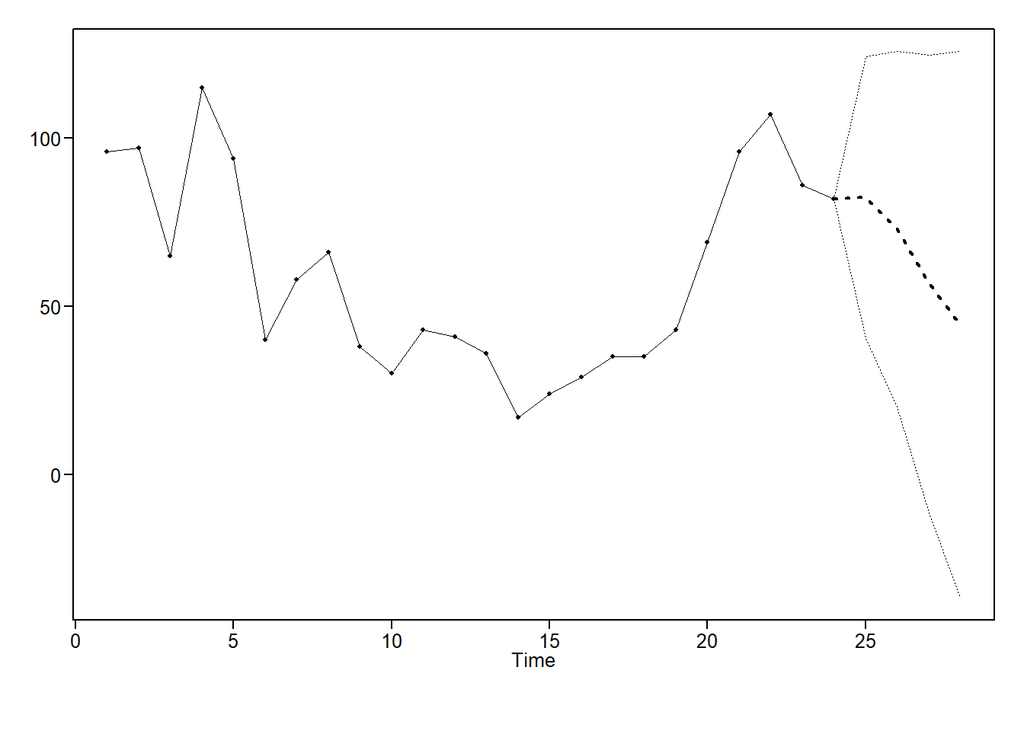

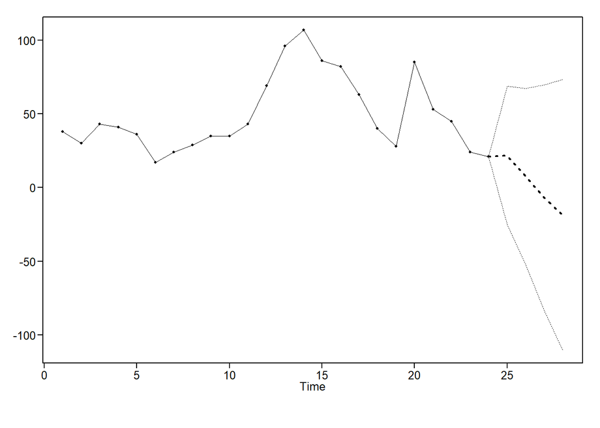

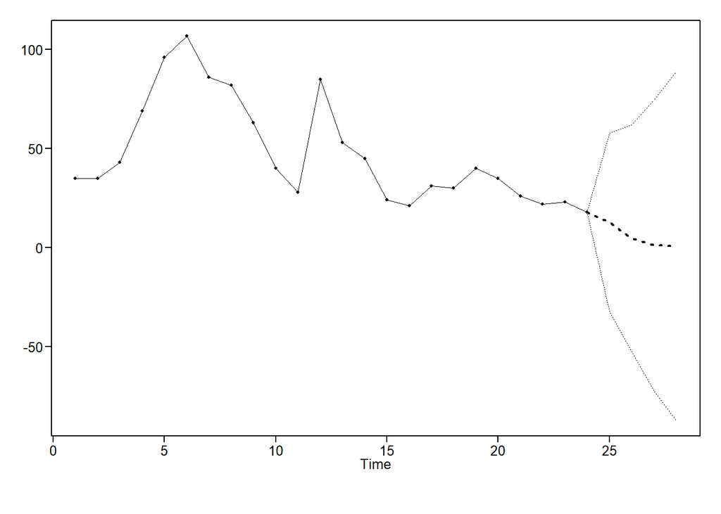

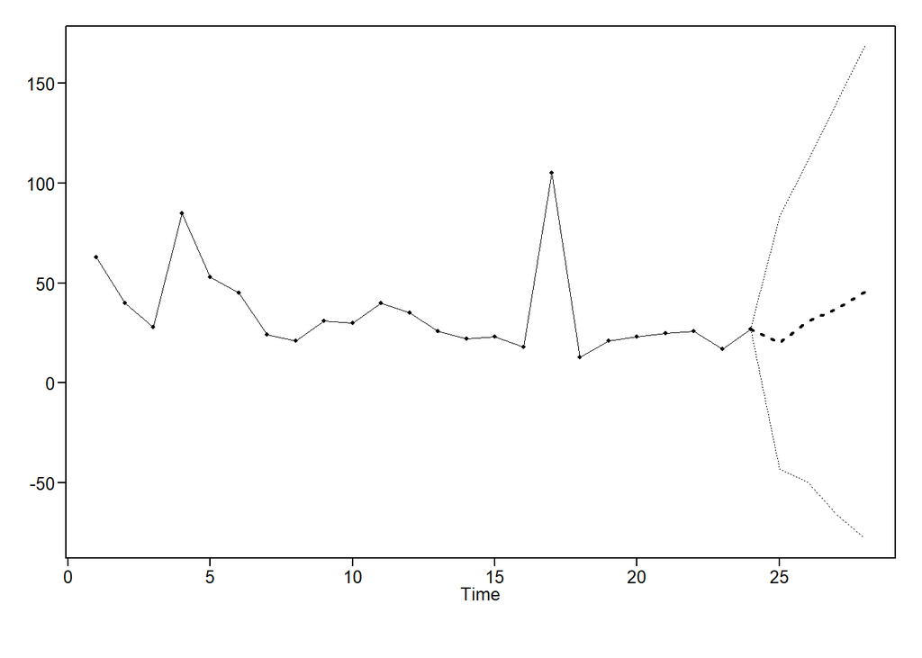

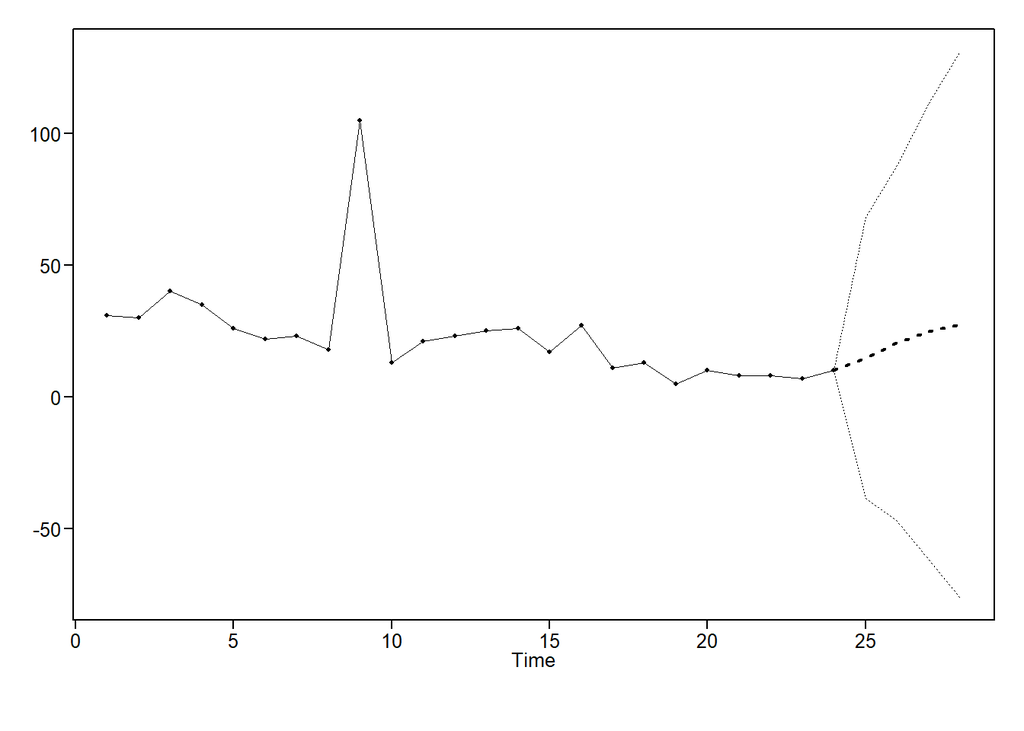

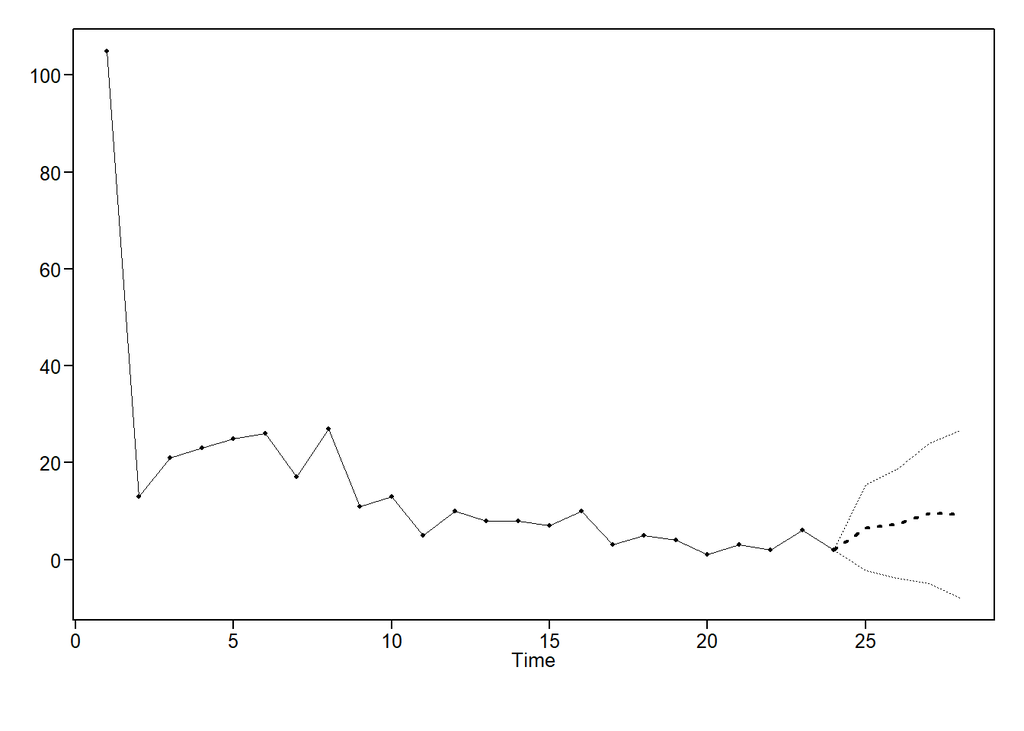

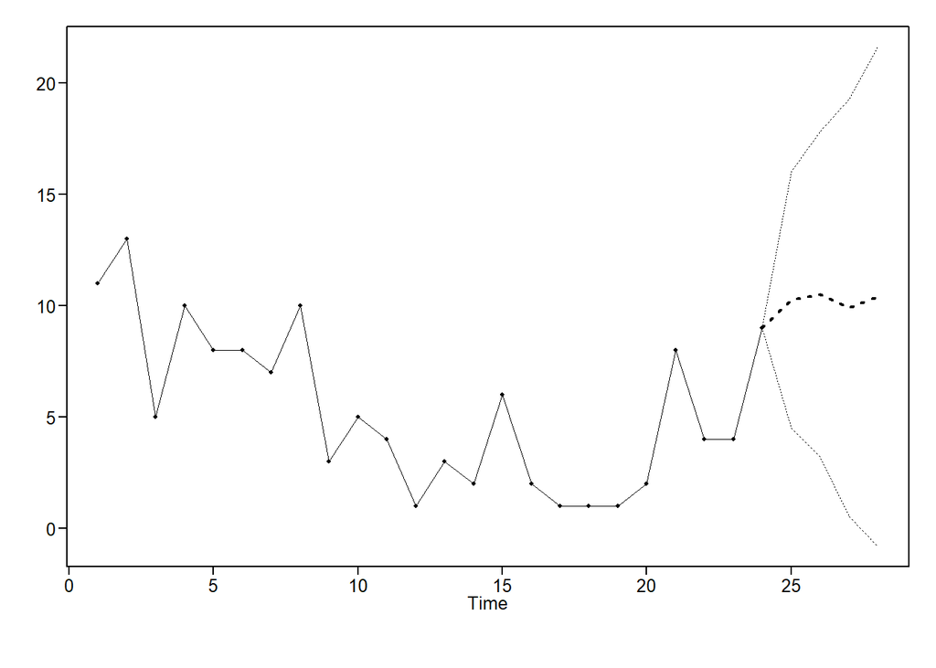

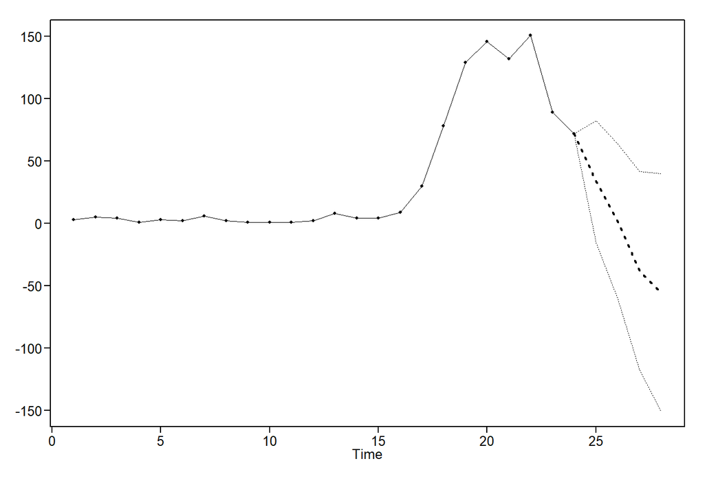

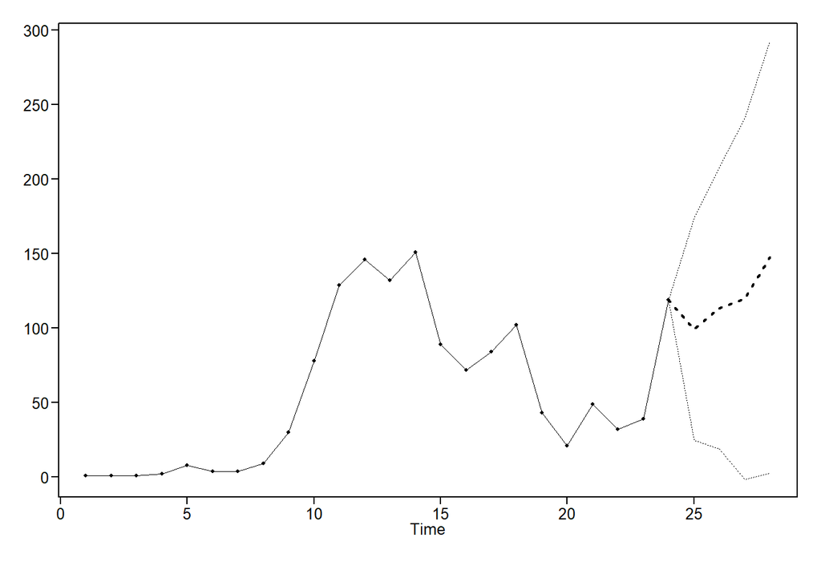

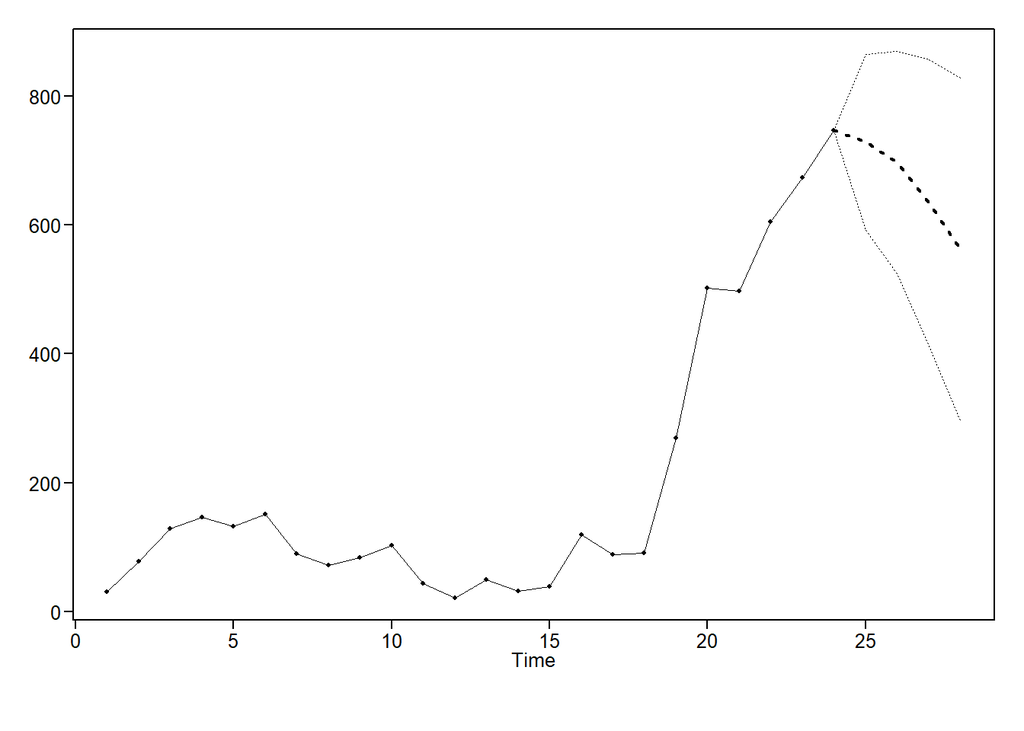

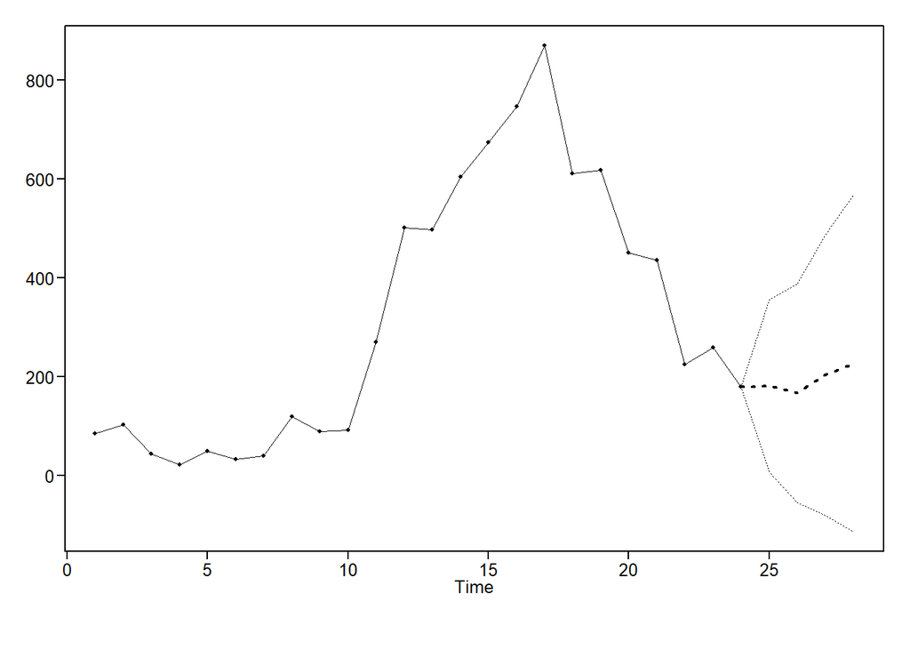

[3 more figures not shown]

```r
ASEHolder
```

```
##  [1]   461.19694   978.48580  1413.84230  2370.38991   672.18770   377.92029
##  [7]    49.51142  9379.33976  6248.70551 37096.95415 10080.37904 10891.45100
## [13]  6623.50866  4791.81958  2590.51611
```

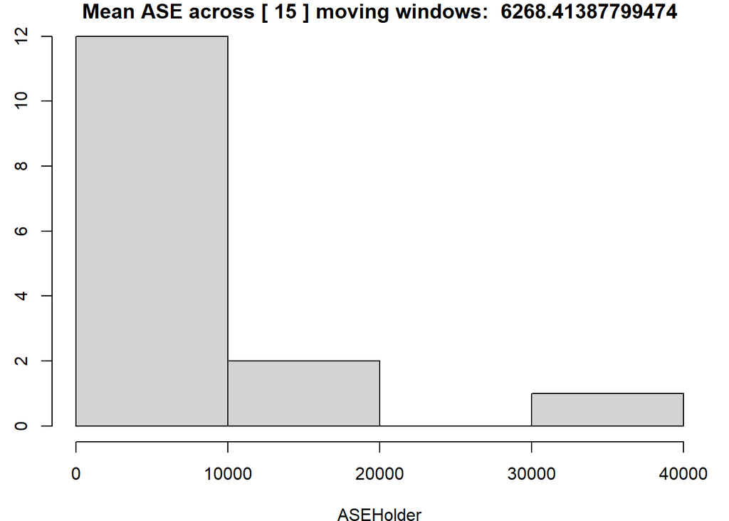

```r
WindowedASE = mean(ASEHolder)
hist(ASEHolder, main = paste("Mean ASE across [", n_windows, '] moving windows: ', WindowedASE))
```

```r
summary(ASEHolder)
```

```
##     Min.  1st Qu.   Median     Mean  3rd Qu.     Max.
##    49.51   825.34  2590.52  6268.41  8001.42 37096.95
```

```r
print(paste("Mean ASE across ", n_windows, ' moving windows: ', WindowedASE))
```

```
## [1] "Mean ASE across  15  moving windows:  6268.41387799474"
```

```r
#function to space out forecasts with NAs for plotting
fspacer <- function(fcasts){
  cast_frame = 0
  cast_frame = matrix(nrow = n_windows, ncol = length(tdata)) #empty matrix to hold spaced out forecasts
  for(i in 1:n_windows)
    {
    #print(i)
    before_block <- rep(NA, (trainingSize + (step_size*(i-1))))
    after_block <- c(rep(NA, (length(tdata) - length(c(rep(NA, (trainingSize + step_size*(i-1))))) - horizon)))
    #print(paste(length(before_block), length(after_block)))
    #print(length(c(before_block, fcasts[i, ], after_block)))
    cast_frame[i, ] <- c(before_block, fcasts[i, ], after_block)
    #print(cast_frame[i, ])
    }
  return(cast_frame)
}
f_spaced <- fspacer(fcastHolder)
```

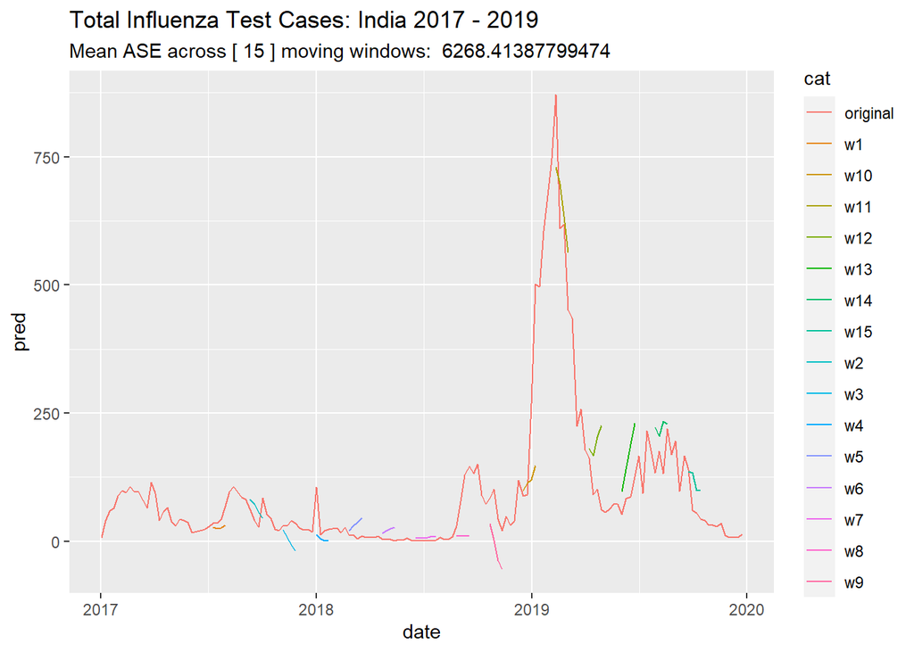

```r
#create categorical dataframe to store windowed predictions
f_spaced <- fspacer(fcastHolder)
fframe <- list()
for(i in 1:n_windows){
  #name = paste0('df', i)
  lname = paste0('w', i)
  #assign(name, data.frame(date = ttime, pred = f_spaced[i, ]))
  tmp <- data.frame(date = ttime, pred = f_spaced[i, ])
  fframe[[lname]] <- tmp
  }
f_df <- cbind(cat= rep(names(fframe), sapply(fframe, NROW)), do.call(rbind, fframe)) #arrange data with category by prediction window
o_df <- data.frame(cat = rep('original', length(tdata)), date = ttime, pred = tdata) #add actual data as rbind
f_df <- rbind(f_df, o_df)

ggplot(f_df, aes(date,pred, color= cat)) + geom_line() +
  ggtitle("Total Influenza Test Cases: India 2017 - 2019", subtitle = paste("Mean ASE across [", n_windows, '] moving windows: ', WindowedASE))
```

```r
year_range = 1995:2019
range_data = vector()
for(j in year_range[1:5]){
  range_data <- rbind(range_data, t_ind[which(t_ind$Year == j), ])
}
```

#iterable years

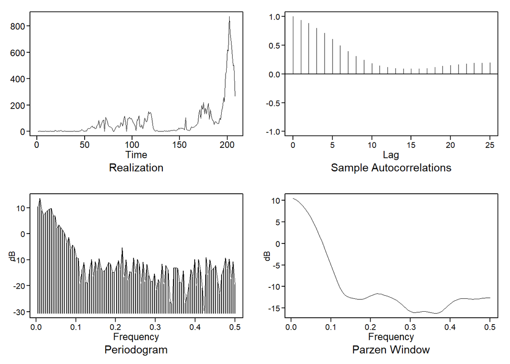

```r
#dataset generation
S_Asia <- raw_data[which(raw_data$FLUREGION == 'Southern Asia'), ]
t_ind <- S_Asia[which(S_Asia['ï..Country'] == 'India'), ] #leave na, convert to zero
t_ind$ALL_INF[is.na(t_ind$ALL_INF)] <- 0

year_range = 2019:1995 #call with year_range[1], ect
n_years = 4 #this can be a user input type thing? starting from 2019, number of years to include in TS
range_data = vector()

for(j in 1:n_years){
  range_data <- rbind(range_data, t_ind[which(t_ind$Year == year_range[j]), ])
} #there we go, creates a df based on specified index years
tdata <- rev(range_data$ALL_INF) #set primary ts to all influenza cases #IMPORTANT to reverse the data
ttime <- rev(range_data$SDATE) %>% as.Date("%m/%d/%Y") %>% sort()#because it's in descending year from indexing scheme

#### model diagnostics ####
invisible(plotts.sample.wge(tdata)) #wrap objects in invisible() to hide the long console output and leave only the graph
```

```r
#stationarity testing
adf.test(tdata)
```

```
##
##  Augmented Dickey-Fuller Test
##
## data:  tdata
## Dickey-Fuller = -6.0686, Lag order = 5, p-value = 0.01
## alternative hypothesis: stationary
```

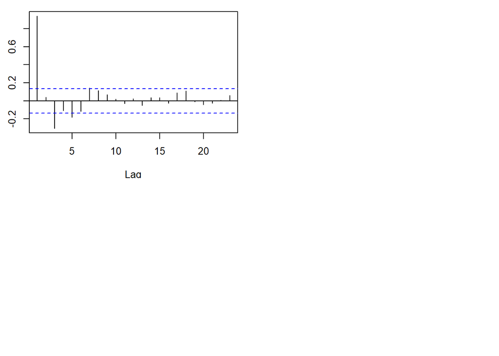

```r
pacf(tdata)
#changepoint
par(mfrow = c(2,1))
```

```r
v2 <- tdata #changepoint visualization
v2.pelt <- cpt.meanvar(v2, test.stat = 'Poisson', method = "PELT")
plot(v2.pelt, main = 'PELT changes in variance')
cpts.ts(v2.pelt)
```

```
##  [1]  44  52  62  71  74  79  81  87  90  92  94 100 102 104 107 112 116 120 122
## [20] 140 148 155 157 161 167 169 172 180 183 193 195 197 199 201 203 205
```

```r
v2.bs <- cpt.meanvar(v2, test.stat = 'Poisson', method = 'BinSeg')
```

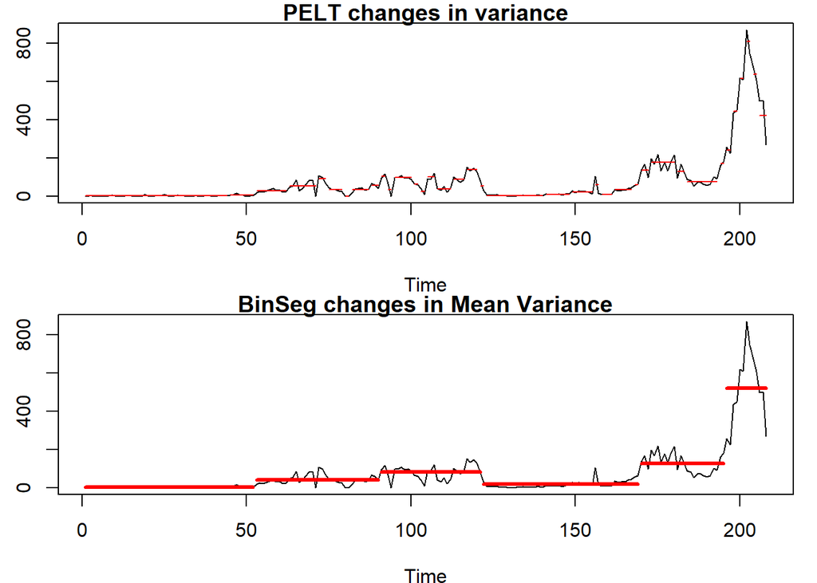

```r
plot(v2.bs, cpt.width = 3, main = 'BinSeg changes in Mean Variance')
```

```r
cpts.ts(v2.bs)
```

```
## [1]  52  90 121 169 195
```

```r
#### end ####

#### model fitting ####
pspan = 0:5 #range of values to look for possible p and q coefficients for AR and MA
qspan = 0:5
difference = 0
aic_results <- aic5.wge(tdata, p = pspan, q = qspan) #cut bic results
```

```
## ---------WORKING... PLEASE WAIT...
##
##
## Five Smallest Values of  aic
```

```r
aic_results
```

```
##       p    q        aic
## 29    4    4   7.353360
## 24    3    5   7.364565
## 30    4    5   7.373713
## 11    1    4   7.376669
## 17    2    4   7.382332
```

```r
m1 = est.arma.wge(tdata, p = aic_results[1, 1], q = aic_results[1, 2], factor = TRUE) #feed top AIC into arma estimation to generate coefficients
```

```
##
## Coefficients of Original polynomial:
## 0.4298 0.9433 0.1995 -0.7044
##
## Factor                 Roots                Abs Recip    System Freq
## 1-1.8492B+0.8903B^2    1.0386+-0.2112i      0.9435       0.0319
## 1+1.4194B+0.7912B^2   -0.8970+-0.6777i      0.8895       0.3970
##
##
```

```r
m1$phi
```

```
## [1]  0.4298149  0.9433382  0.1994705 -0.7043920
```

```r
m1$theta
```

```
## [1] -0.3553471  0.1804677  0.3758103 -0.3824985
```

```r
#### end ####


#### endpoint forcast ####
#simple single forecast and test
weeks_compare = 24 #how many weeks to reserve for testing : 6months
f1 <- tdata[1:(length(tdata)-weeks_compare)] %>% fore.aruma.wge(phi = m1$phi, theta = m1$theta, d = 0, n.ahead = weeks_compare)
```

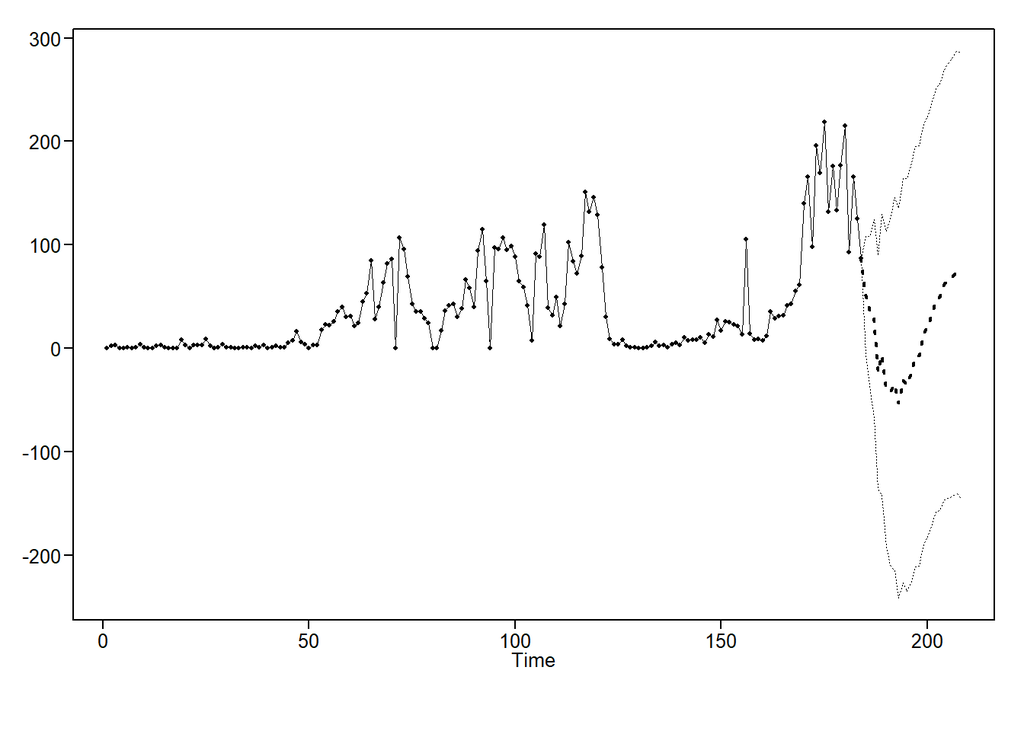

```r
mse <- mean((tdata[((length(tdata)-weeks_compare)+1):(length(tdata))] - f1$f)^2)
paste('Mean Squared Error: ', mse)
```

```
## [1] "Mean Squared Error:  150545.966241419"
```

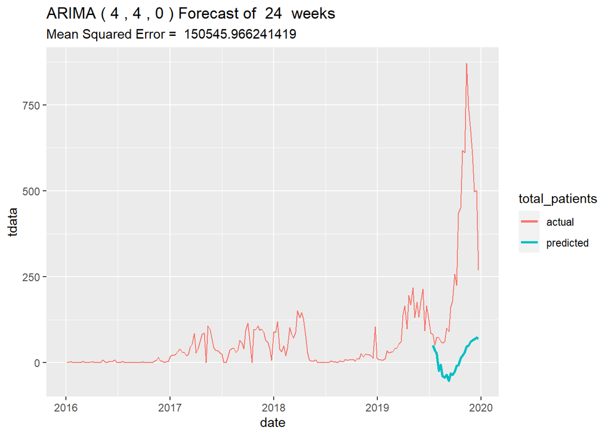

```r
#additional metrics
a_metrics <- accuracy(f1$f, tdata[((length(tdata)-weeks_compare)+1):(length(tdata))] )

#change x and y line names to match whatever dataframe you've stored the time series in
timeFrame <- data.frame(date = ttime, inf_cases = tdata)
g3 <- ggplot(timeFrame)+
  geom_line(aes(x = date, y = tdata, color = 'black'), size = 0.5)+
  geom_line(aes(x = date, y = c(rep(NA, (length(tdata)-weeks_compare)), f1$f), color = 'red'), size= 1) +
  scale_color_discrete(name = "total_patients", labels = c('actual', 'predicted')) +
  ggtitle(paste('ARIMA (',aic_results[1, 1],',',aic_results[1, 2],',',difference,')', 'Forecast of ', weeks_compare, ' weeks'), subtitle = paste('Mean Squared Error = ', mse))
g3
```

```r
#### end ####

#### rolling window ase and viz ####
#rolling window ase: apply model predictions to small segments of the given data and aggregate metrics
trainingSize = 24
horizon = 4 #3months
step_size = 4
n_windows = round((length(tdata)-(trainingSize + horizon))/step_size) #number of whole windows of training size + horizon that will fit into the given data, divided by step size
ASEHolder = numeric()

fcastHolder = matrix(nrow = n_windows, ncol = horizon) #create matrix that has the number of rows and columns corresponding to number of windows and length of forecast interval
fUpperHolder = matrix(nrow = n_windows, ncol = horizon) #same for upper and lower intervals
fLowerHolder = matrix(nrow = n_windows, ncol = horizon)
phis = m1$phi
thetas = m1$theta
s = 0
d = 0
for( i in 1:n_windows) #how many "windows" can fit into the total length of time, rounding down
{
  t_start = 1+(step_size*(i-1)) #starting point for each window's training data
  t_end = trainingSize + (step_size*(i-1)) #endpoint
  forecasts = fore.aruma.wge(tdata[t_start:t_end],phi = phis, theta = thetas, s = s, d = d, n.ahead = horizon, plot = FALSE)
  ASE = mean((tdata[(t_end + 1):(t_end+horizon)] - forecasts$f)^2)
  ASEHolder[i] = ASE
  fcastHolder[i, ] <- forecasts$f
  fUpperHolder[i, ] <- forecasts$ul
  fLowerHolder[i, ] <- forecasts$ll
}
summary(ASEHolder)
```

```
##     Min.  1st Qu.   Median     Mean  3rd Qu.     Max.
##     1.31   136.74   781.16  3014.09  2970.89 32876.32
```

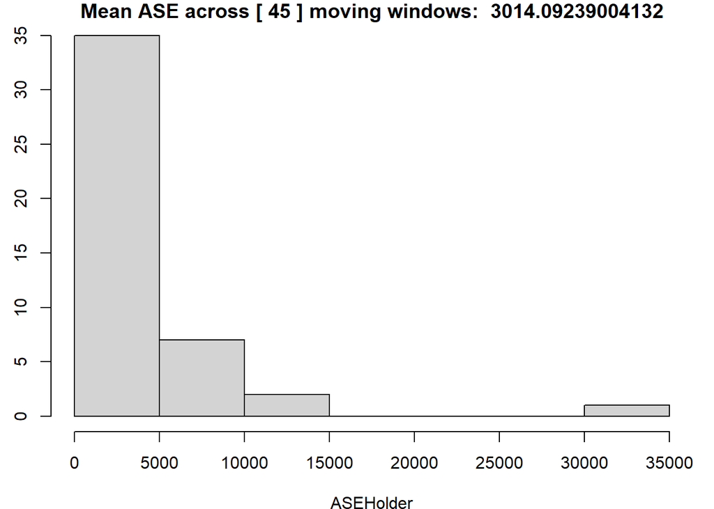

```r
WindowedASE = mean(ASEHolder)
hist(ASEHolder, main = paste("Mean ASE across [", n_windows, '] moving windows: ', WindowedASE))
```

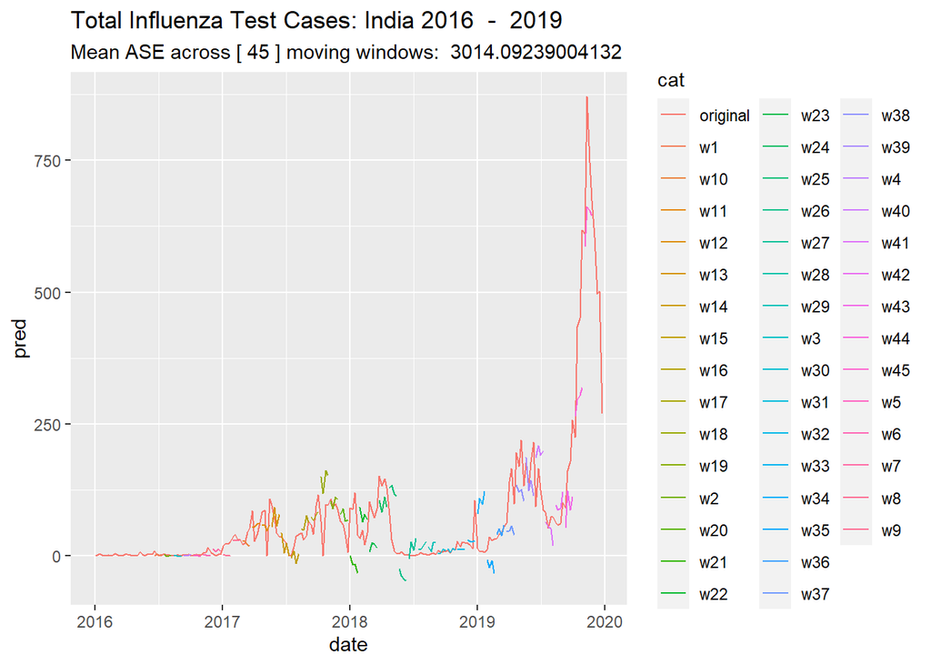

```r
#### end ####

#### create categorical dataframe to store windowed predictions and visualize with ggplot ####
f_spaced <- fspacer(fcastHolder)
fframe <- list()
for(i in 1:n_windows){
  #name = paste0('df', i)
  lname = paste0('w', i)
  #assign(name, data.frame(date = ttime, pred = f_spaced[i, ]))
  tmp <- data.frame(date = ttime, pred = f_spaced[i, ])
  fframe[[lname]] <- tmp
  }
f_df <- cbind(cat= rep(names(fframe), sapply(fframe, NROW)), do.call(rbind, fframe)) #arrange data with category by prediction window
o_df <- data.frame(cat = rep('original', length(tdata)), date = ttime, pred = tdata) #add actual data as rbind
f_df <- rbind(f_df, o_df)

ggplot(f_df, aes(date,pred, color= cat)) + geom_line() +
  ggtitle(paste("Total Influenza Test Cases: India", year_range[1:n_years][n_years], ' - ', year_range[1:n_years][1]), subtitle = paste("Mean ASE across [", n_windows, '] moving windows: ', WindowedASE))
```

```r
#### end ####
```

#determine optimal # of years for forecast with ASE